# Prosperidad y apoyo a proyectos sobre ciencia y tecnología en la UNMSM y la PUCP - Entrega P4

Se intentan corregir las gráficas:

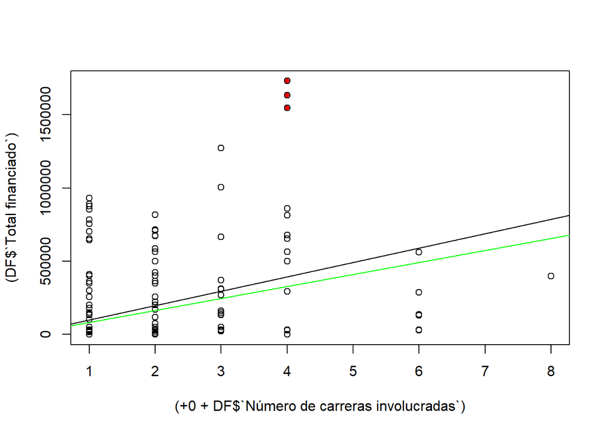

```r
plot(x=(+0 + DF$`Número de carreras involucradas`),y=(DF$`Total financiado`))
points(+0 + DF$`Número de carreras involucradas`[71],DF$`Total financiado`[71],pch=20,col="red")
points(+0 + DF$`Número de carreras involucradas`[62],DF$`Total financiado`[62],pch=20,col="red")
points(+0 + DF$`Número de carreras involucradas`[11],DF$`Total financiado`[11],pch=20,col="red")
lt6<-lm(DF$`Total financiado`[-71][-62][-11]~+0 + DF$`Número de carreras involucradas`[-71][-62][-11])
abline(lt5)
abline(lt6,col="green")
```

```r
summary(lt6)
```

```
##
## Call:
## lm(formula = DF$`Total financiado`[-71][-62][-11] ~ +0 + DF$`Número de carreras involucradas`[-71][-62][-11])
##
## Residuals:
##     Min      1Q  Median      3Q     Max
## -461627 -133576  -46556  227530 1027576
##
## Coefficients:
##                                                     Estimate Std. Error t value
## DF$`Número de carreras involucradas`[-71][-62][-11]    81788      10322   7.924
##                                                     Pr(>|t|)
## DF$`Número de carreras involucradas`[-71][-62][-11] 9.08e-13 ***
## ---
## Signif. codes:  0 '***' 0.001 '**' 0.01 '*' 0.05 '.' 0.1 ' ' 1
##
## Residual standard error: 309800 on 130 degrees of freedom
##   (16 observations deleted due to missingness)
## Multiple R-squared:  0.3257, Adjusted R-squared:  0.3205
## F-statistic: 62.78 on 1 and 130 DF,  p-value: 9.08e-13
```

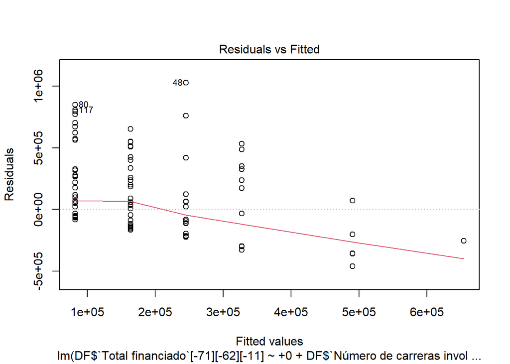

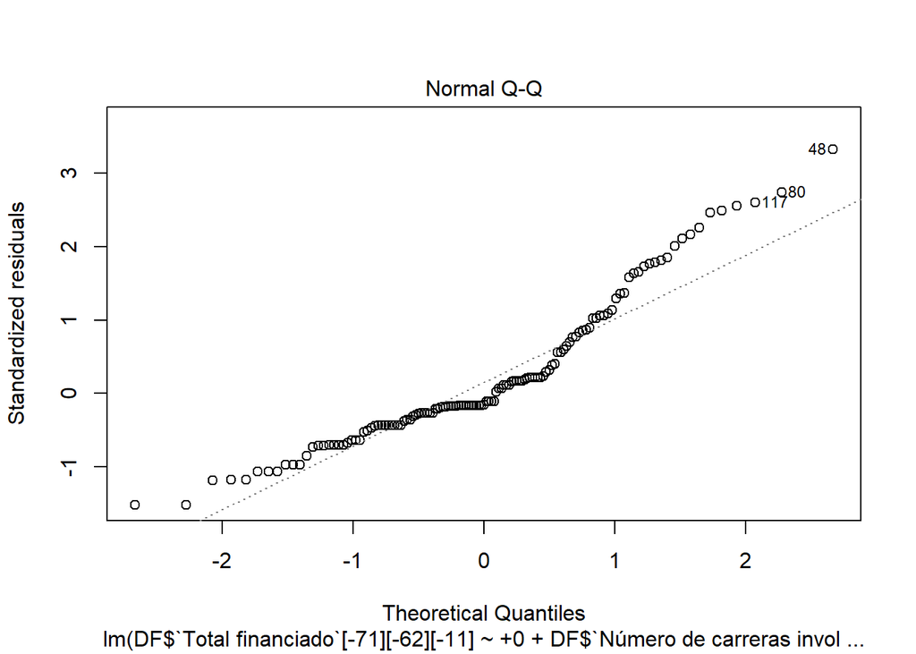

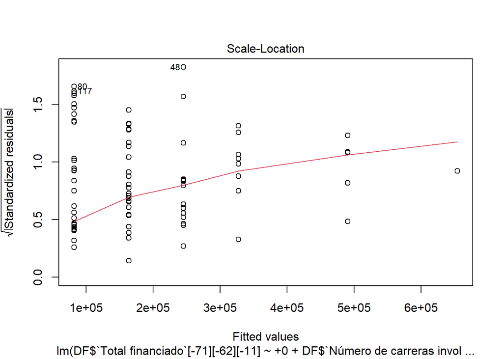

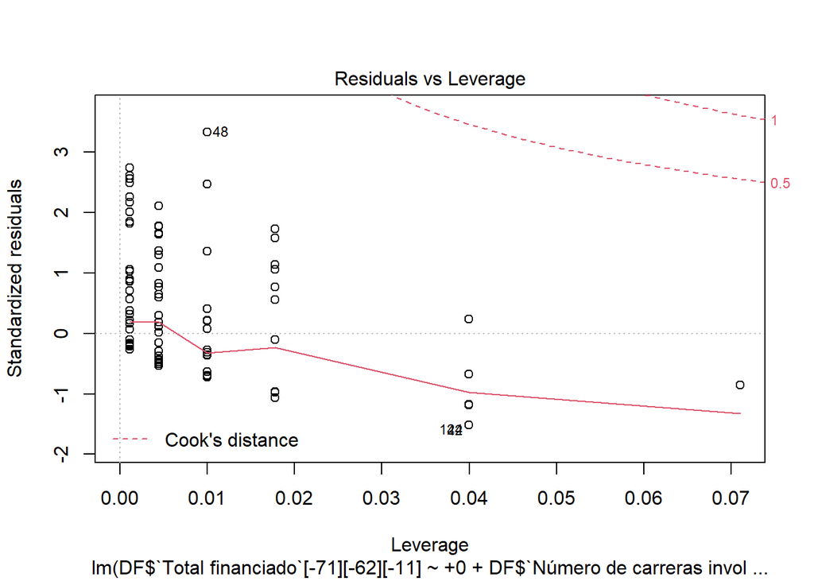

```r
plot(lt6)
```

Eliminando los 3 puntos, se sigue teniendo una relación, no obstante este valor disminuye en algo. Sin los últimos 3 puntos, la regresión es significante, y muestra significancia entre el número de carreras involucradas y el total financiado.

Se tiene la siguiente dependencia:
$$TotalFinanciado(c)=81788c$$

# Conclusiones

- La financiación obtenida por parte de CONCYTEC es sumamente importante porque representa la mayor fuente de financiación de proyectos para la PUCP y la UNMSM. Las financiación por parte de la universidad es también importante porque es la fuente de financiación mas común entre los proyectos, aunque, en general, no brinde cantidades muy grandes de dinero.
- Las diferentes áreas de investigación no reciben la misma financiación, existe una predilección por financiar proyectos de ingeniería, además, los proyectos de Medicina, en general, reciben poca financiación en comparación a las otras áreas.
- Aparentemente, existe una dependencia entre la cantidad financiada y la cantidad de áreas que involucran los proyectos. Es una relación lógica pues si el proyecto abarca más áreas del conocimiento es más versátil y tiene posibilidad de tener más impacto.
- Con un 95% de confianza podemos afirmar que la muestra financiada por CONCYTEC no es realmente representativa pues su media fue diferente a la teórica.
- Con un 95% de confianza podemos afirmar que la muestra financiada por las universidades PUCP y UNMSM es representativa pues no se rechazaron las hipótesis nulas.
- Tenemos evidencia, como para afirmar, con un 95% de confianza, que la financiación total de los proyectos tiende a disminuir conforme pasan los años.